# Predicting Shelter Outcomes

W01G04

## 1. Problem Framing & Research Question

Animal center accepts a variety of animals from wildlife to owned pet. Our dataset is Austin Animal Center Outcomes from official city of Austin open data portal showing information of animals with outcomes such as return to owner, adoption, etc. We will investigate which animal characteristics are associated with different shelter outcomes and aim to predict the outcomes of dogs and cats using information available at intake.

**Task and relevance:** Predict the final outcome of cats and dogs—Adoption, Transfer, Return, Euthanasia, or Other—from information available at intake. This real-world task is relevant to shelters managing overcrowding and limited resources.

**Stakeholders:** Shelter staff, animal-care teams, adoption and transfer coordinators, and managers allocating shelter resources.

**Research question:** To what extent can intake-time information of cats and dogs predict these five shelter outcomes for each animal’s latest recorded admission?

**Motivation:** Early predictions may help staff prioritise care, allocate resources, and identify animals at greater risk of unfavourable outcomes.

## 2. Dataset & Justification

#### Data Source(s)

The [Austin Animal Center Outcomes](https://data.austintexas.gov/d/gsvs-ypi7) dataset is published by the City of Austin Open Data Portal and maintained by Austin Animal Services.

#### Dataset Justification

1. **Large Size (>10,000 observations)**

2. **Messy (missing values)**

3. **Multi-class（5 classes）**

The cat-and-dog subset contains **28 distinct raw `Outcome.Status` categories**. Many are administrative variations of the same terminal outcome, while several contain only a few observations. Retaining all 28 would create sparse classes, unstable estimates, and unreliable cross-validation. We therefore consolidate categories with the same operational meaning into five outcomes:

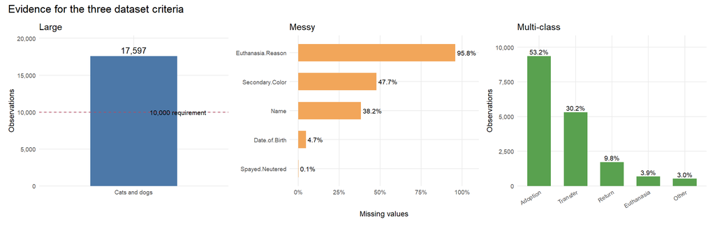

```r
knitr::opts_chunk$set(
  message = FALSE,
  warning = FALSE
)

library(tidyr)
library(dplyr)
library(stringr)
library(forcats)
library(ggplot2)
library(scales)
library(patchwork)

# The CSV is stored in the same folder as this R Markdown file.
data <- read.csv(
  "Austin_Animal_Center_Outcomes_20260916.csv",
  stringsAsFactors = TRUE
)

# Restrict the scope to cats and dogs and consolidate the 28 raw outcomes.
data_selected <- data %>%
  filter(Type %in% c("Dog", "Puppy", "Cat", "Kitten")) %>%
  mutate(
    Outcome.Group = case_when(
      str_detect(Outcome.Status, regex("Adopt", ignore_case = TRUE)) ~ "Adoption",
      str_detect(Outcome.Status, regex("Transfer", ignore_case = TRUE)) ~ "Transfer",
      str_detect(Outcome.Status, regex("Euthan", ignore_case = TRUE)) ~ "Euthanasia",
      str_detect(
        Outcome.Status,
        regex("Reclaim|Redemption|Returned To Owner|Return to Habitat", ignore_case = TRUE)
      ) ~ "Return",
      TRUE ~ "Other"
    ),
    Outcome.Group = factor(
      Outcome.Group,
      levels = c("Adoption", "Transfer", "Return", "Euthanasia", "Other")
    )
  )

group_summary <- data_selected %>%
  count(Outcome.Group, name = "Count") %>%
  mutate(
    Percentage = 100 * Count / sum(Count),
    Outcome.Group = factor(Outcome.Group, levels = levels(data_selected$Outcome.Group))
  )

key_missing <- c(
  "Name", "Euthanasia.Reason", "Secondary.Color",
  "Date.of.Birth", "Spayed.Neutered"
)

missing_summary <- tibble(
  Feature = key_missing,
  Missing_Pct = sapply(
    key_missing,
    function(feature) {
      values <- data_selected[[feature]]
      100 * mean(is.na(values) | trimws(as.character(values)) == "")
    }
  )
) %>%
  arrange(Missing_Pct) %>%
  mutate(Feature = factor(Feature, levels = Feature))

p_large <- ggplot(
  tibble(Scope = "Cats and dogs", Observations = nrow(data_selected)),
  aes(x = Scope, y = Observations)
) +
  geom_col(width = 0.55, fill = "#4C78A8") +
  geom_hline(yintercept = 10000, linetype = "dashed", colour = "#B24C63") +
  geom_text(aes(label = scales::comma(Observations)), vjust = -0.4, size = 3.5) +
  annotate("text", x = 1.28, y = 10000, label = "10,000 requirement", size = 2.8) +
  scale_y_continuous(labels = scales::comma, expand = expansion(mult = c(0, 0.16))) +
  labs(title = "Large", x = NULL, y = "Observations") +
  theme_minimal(base_size = 9) +
  theme(panel.grid.minor = element_blank())

p_missing <- ggplot(missing_summary, aes(x = Feature, y = Missing_Pct)) +
  geom_col(width = 0.6, fill = "#F2A65A") +
  geom_text(
    aes(label = sprintf("%.1f%%", Missing_Pct)),
    hjust = -0.1,
    size = 2.8
  ) +
  coord_flip() +
  scale_y_continuous(
    limits = c(0, 105),
    breaks = c(0, 25, 50, 75, 100),
    labels = scales::label_percent(scale = 1)
  ) +
  labs(title = "Messy", x = NULL, y = "Missing values") +
  theme_minimal(base_size = 9) +
  theme(panel.grid.minor = element_blank())

p_class <- ggplot(group_summary, aes(x = Outcome.Group, y = Count)) +
  geom_col(width = 0.65, fill = "#59A14F") +
  geom_text(
    aes(label = sprintf("%.1f%%", Percentage)),
    vjust = -0.35,
    size = 2.8
  ) +
  scale_y_continuous(labels = scales::comma, expand = expansion(mult = c(0, 0.16))) +
  labs(title = "Multi-class", x = NULL, y = "Observations") +
  theme_minimal(base_size = 9) +
  theme(
    panel.grid.minor = element_blank(),
    axis.text.x = element_text(angle = 30, hjust = 1)
  )

criteria_plot <- p_large + p_missing + p_class +
  plot_annotation(title = "Evidence for the three dataset criteria")

print(criteria_plot)
```

## 3. EDA & Insights

**1. Dataset Overview and Data Quality** — the original outcomes file contains 18,624 records and 16 columns. Each row represents an outcome record, and the same animal may appear in more than one record. The original columns include identifiers, animal characteristics, outcome information, dates and administrative metadata; they are not all predictors.

**Original dataset variables.** The table below introduces all original columns using their CSV names; planned transformations are implemented only in Data Preprocessing. In the R code, `read.csv()` converts spaces and punctuation to dots, for example `Animal ID` becomes `Animal.ID` and `Spayed/Neutered` becomes `Spayed.Neutered`.

| Original column | Meaning and role | Data type | Planned analytical use |
| --- | --- | --- | --- |
| `ID` | Identifier for an individual record | Identifier | Record checks; excluded from predictors |
| `Outcome Date` | Recorded date and time of the outcome | Date/time | Excluded: unavailable at intake |
| `Animal ID` | Identifier linking records for the same animal | Identifier | Select each animal’s latest intake record during preprocessing; excluded from predictors |
| `Name` | Recorded animal name | Text | Derive `has_Name` |
| `Outcome Status` | Recorded outcome category | Categorical | Consolidate into the response `Outcome.Group`; excluded from predictors |
| `Euthanasia Reason` | Recorded reason for euthanasia, where applicable | Text/categorical | Excluded: outcome-related information |
| `Type` | Recorded animal type, including species and life-stage labels | Categorical | Select Dog/Puppy/Cat/Kitten records, then recode to Dog/Cat |
| `Sex` | Recorded sex | Categorical | Standardise as `Sex` |
| `Spayed/Neutered` | Recorded spay/neuter status | Categorical | Standardise as `Spayed.Neutered`; verify intake-time availability |
| `Primary Breed` | Recorded primary breed | Categorical | Derive `primary.breed.group` |
| `Primary Color` | Recorded primary coat colour or pattern description | Categorical | Derive `Base_Color` and contribute to `has_pattern` |
| `Secondary Color` | Recorded secondary coat colour, if present | Categorical | Contribute to `has_pattern` |
| `Date of Birth` | Recorded birth date | Date/time | Combine with intake date to derive `Age_Years` |
| `Intake Date` | Recorded date and time of intake | Date/time | Select the latest intake record and combine with birth date to derive `Age_Years` |
| `Days in Shelter` | Recorded duration of the shelter stay | Numeric | Excluded: completed stay duration is unavailable at intake |
| `Timestamp` | Timestamp supplied with the record | Date/time metadata | Excluded: administrative metadata |

**Analysis scope.** EDA examines the 17,597 selected records using their original predictor values. The `data_eda` object remains an unchanged copy of `data_selected` throughout this section. Separate audit and plotting summaries describe missingness, inconsistencies and associations with `Outcome.Group`. The original colour figure uses its own separate plotting copy to reproduce the v12 categories. Selection of each animal’s latest intake record, model-input construction, invalid-value replacement, imputation, splitting, encoding and scaling begin in Data Preprocessing. The EDA summaries therefore describe the initial records, before selection of the final modelling sample.

**Data-quality checks.** Date differences are calculated to inspect age at intake. Negative results are retained as negative values in the audit and counted separately from missing dates. No age is replaced or imputed during EDA.

```r
library(lubridate)

# EDA audit helpers: inspect blanks and read date strings without changing the source.
is_blank <- function(x) {
  is.na(x) | trimws(as.character(x)) == ""
}

parse_shelter_date <- function(x) {
  as.Date(parse_date_time(
    as.character(x),
    orders = c("Y b d I M S p", "ymd HMS", "mdy HMS", "dmy HMS",
               "ymd", "mdy", "dmy"),
    locale = "C", tz = "UTC", quiet = TRUE
  ))
}

# Keep this copy unchanged throughout EDA.
data_eda <- data_selected

# age check
age_audit <- tibble(
  DOB = parse_shelter_date(data_eda$Date.of.Birth),
  Intake_Date = parse_shelter_date(data_eda$Intake.Date)
) %>%
  mutate(Age_Years_raw = as.numeric(Intake_Date - DOB) / 365)

quality_features <- c(
  "Type", "Sex", "Spayed.Neutered", "Primary.Breed",
  "Primary.Color", "Secondary.Color", "Name", "Date.of.Birth", "Intake.Date"
)
quality_summary <- tibble(
  Feature = quality_features,
  Distinct_nonblank = sapply(quality_features, function(v) {
    x <- as.character(data_eda[[v]])
    n_distinct(x[!is_blank(x)])
  }),
  Missing_n = sapply(quality_features, function(v) sum(is_blank(data_eda[[v]]))),
  Missing_pct = 100 * Missing_n / nrow(data_eda),
  Unknown_label_n = sapply(quality_features, function(v) {
    sum(str_to_lower(trimws(as.character(data_eda[[v]]))) == "unknown",
        na.rm = TRUE)
  })
)
knitr::kable(quality_summary, digits = 2,
             caption = "Raw-field quality in the complete cat-and-dog subset")
```

Raw-field quality in the complete cat-and-dog subset

| Feature | Distinct_nonblank | Missing_n | Missing_pct | Unknown_label_n |
| --- | --- | --- | --- | --- |
| Type | 4 | 0 | 0.00 | 0 |
| Sex | 3 | 21 | 0.12 | 1878 |
| Spayed.Neutered | 4 | 17 | 0.10 | 2377 |
| Primary.Breed | 198 | 0 | 0.00 | 2 |
| Primary.Color | 109 | 0 | 0.00 | 23 |
| Secondary.Color | 82 | 8396 | 47.71 | 0 |
| Name | 5458 | 6716 | 38.17 | 161 |
| Date.of.Birth | 2977 | 828 | 4.71 | 0 |
| Intake.Date | 11137 | 0 | 0.00 | 0 |

```r
quality_checks <- tibble(
  Check = c("Records", "Distinct nonmissing Animal IDs", "Exact duplicate rows",
            "Animal IDs with more than one record", "Missing Animal IDs",
            "Nonblank birth dates that failed parsing",
            "Nonblank intake dates that failed parsing",
            "Age unavailable from dates", "Negative ages observed"),
  Count = c(
    nrow(data_eda),
    n_distinct(data_eda$Animal.ID[!is_blank(data_eda$Animal.ID)]),
    sum(duplicated(data_eda)),
    sum(table(data_eda$Animal.ID[!is_blank(data_eda$Animal.ID)]) > 1),
    sum(is_blank(data_eda$Animal.ID)),
    sum(!is_blank(data_eda$Date.of.Birth) & is.na(age_audit$DOB)),
    sum(!is_blank(data_eda$Intake.Date) & is.na(age_audit$Intake_Date)),
    sum(is.na(age_audit$Age_Years_raw)),
    sum(age_audit$Age_Years_raw < 0, na.rm = TRUE)
  )
)
knitr::kable(quality_checks, caption = "Record and date checks")
```

Record and date checks

| Check | Count |
| --- | --- |
| Records | 17597 |
| Distinct nonmissing Animal IDs | 16831 |
| Exact duplicate rows | 0 |
| Animal IDs with more than one record | 676 |
| Missing Animal IDs | 0 |
| Nonblank birth dates that failed parsing | 0 |
| Nonblank intake dates that failed parsing | 0 |
| Age unavailable from dates | 828 |
| Negative ages observed | 90 |

The audit identifies 828 unavailable ages and a further 90 negative ages. These are separate data-quality findings. Negative ages remain in the audit; their conversion to missing values is a later preprocessing decision. Repeated Animal IDs may represent separate shelter episodes rather than duplicate records. To use one observation per animal for modelling, the first preprocessing step retains each animal’s most recent recorded intake.

```r
# These functions aggregate observed categories
outcome_colours <- setNames(
  c("#66C2A5", "#FC8D62", "#8DA0CB", "#E78AC3", "#A6D854"),
  levels(data_eda$Outcome.Group)
)

outcome_summary <- function(df, feature) {
  df %>%
    mutate(Level = as.character(.data[[feature]])) %>%
    select(Level, Outcome.Group) %>%
    count(Level, Outcome.Group, .drop = FALSE) %>%
    group_by(Level) %>%
    mutate(Total = sum(n), Prop = n / Total) %>%
    ungroup()
}

# Axis labels distinguish NA, blanks and whitespace without changing their values.
display_eda_level <- function(x) {
  labels <- as.character(x)
  labels[is.na(x)] <- "<NA>"
  labels[!is.na(x) & x == ""] <- "<blank>"
  whitespace <- !is.na(x) & x != "" & trimws(x) == ""
  labels[whitespace] <- "<whitespace>"
  labels
}

plot_outcome_summary <- function(summary, title) {
  totals <- distinct(summary, Level, Total)
  ggplot(summary, aes(x = Level, y = Prop, fill = Outcome.Group)) +
    geom_col(width = 0.6) +
    scale_x_discrete(labels = function(x) {
      paste0(display_eda_level(x), "\n(n=",
             scales::comma(totals$Total[match(x, totals$Level)]), ")")
    }) +
    scale_y_continuous(labels = percent_format(),
                       expand = expansion(mult = c(0, 0.03))) +
    scale_fill_manual(values = outcome_colours, drop = FALSE) +
    labs(title = title, x = NULL, y = "Within-group proportion", fill = "Outcome") +
    theme_minimal(base_size = 9) +
    theme(plot.title = element_text(face = "bold", size = 10),
          axis.text.x = element_text(angle = 30, hjust = 1),
          panel.grid.minor = element_blank(), legend.position = "bottom")
}

plot_outcome <- function(df, feature, title) {
  plot_outcome_summary(outcome_summary(df, feature), title)
}

plot_outcome_heatmap <- function(summary, title) {
  totals <- distinct(summary, Level, Total)
  ggplot(summary, aes(x = Outcome.Group, y = Level, fill = Prop)) +
    geom_tile(colour = "white") +
    geom_text(aes(label = if_else(Prop >= 0.08, sprintf("%.0f%%", 100 * Prop), "")),
              size = 3) +
    scale_y_discrete(labels = function(x) {
      paste0(display_eda_level(x), " (n=",
             scales::comma(totals$Total[match(x, totals$Level)]), ")")
    }) +
    scale_fill_gradient(low = "#F0F4F8", high = "#1F78B4", labels = percent_format()) +
    labs(title = title, x = NULL, y = NULL, fill = "Proportion") +
    theme_minimal(base_size = 9) +
    theme(plot.title = element_text(face = "bold", size = 10),
          panel.grid = element_blank())
}

outcome_rate <- function(feature, level, outcome) {
  x <- outcome_summary(data_eda, feature)
  index <- !is.na(x$Level) & x$Level == level & x$Outcome.Group == outcome
  value <- x$Prop[index]
  if (length(value) == 0L) return("not observed")
  sprintf("%.1f%%", 100 * value)
}
```

**2. Type and Type-Age Redundancy** — the original four labels are retained throughout EDA. Puppy and Kitten already describe life stage as well as species, so their relationship with observed age indicates overlapping information. The age summaries use only nonnegative observed ages, with missing and negative counts reported separately. The outcome comparison also uses the four original categories; the Dog/Cat recoding is performed later.

```r
# Summarise original Type values
type_age_summary <- tibble(
  Type = data_eda$Type,
  Age_Years_raw = age_audit$Age_Years_raw
) %>%
  group_by(Type, .drop = TRUE) %>%
  summarise(
    n = n(),
    Missing_age = sum(is.na(Age_Years_raw)),
    Negative_age = sum(Age_Years_raw < 0, na.rm = TRUE),
    Median_age = median(Age_Years_raw[!is.na(Age_Years_raw) & Age_Years_raw >= 0]),
    Q1 = quantile(Age_Years_raw[!is.na(Age_Years_raw) & Age_Years_raw >= 0], 0.25),
    Q3 = quantile(Age_Years_raw[!is.na(Age_Years_raw) & Age_Years_raw >= 0], 0.75),
    .groups = "drop"
  )
knitr::kable(type_age_summary, digits = 2,
             caption = "Original Type categories and observed nonnegative age")
```

Original Type categories and observed nonnegative age

| Type | n | Missing_age | Negative_age | Median_age | Q1 | Q3 |
| --- | --- | --- | --- | --- | --- | --- |
| Cat | 9033 | 259 | 43 | 0.33 | 0.12 | 2.00 |
| Dog | 6669 | 202 | 16 | 1.50 | 0.34 | 3.00 |
| Kitten | 1587 | 296 | 19 | 0.08 | 0.04 | 0.13 |
| Puppy | 308 | 71 | 12 | 0.13 | 0.04 | 0.17 |

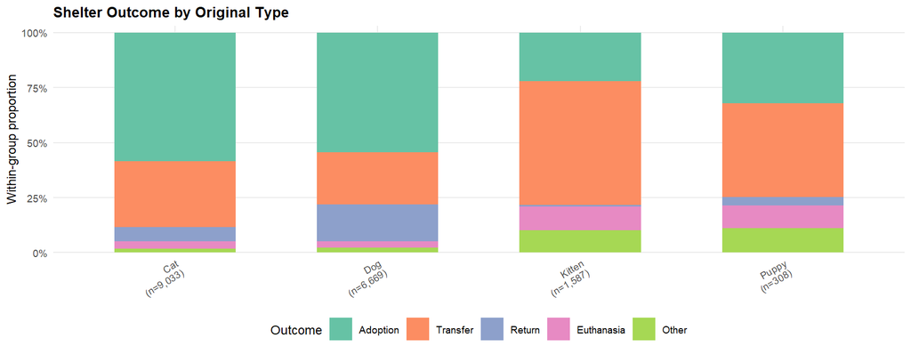

```r
p_type_outcome <- plot_outcome(data_eda, "Type", "Shelter Outcome by Original Type")
print(p_type_outcome)
```

The Return proportions are 16.8% for Dog, 3.9% for Puppy, 6.4% for Cat and 0.6% for Kitten. Alongside the age summaries, these differences motivate representing species and continuous age separately in the modelling dataset.

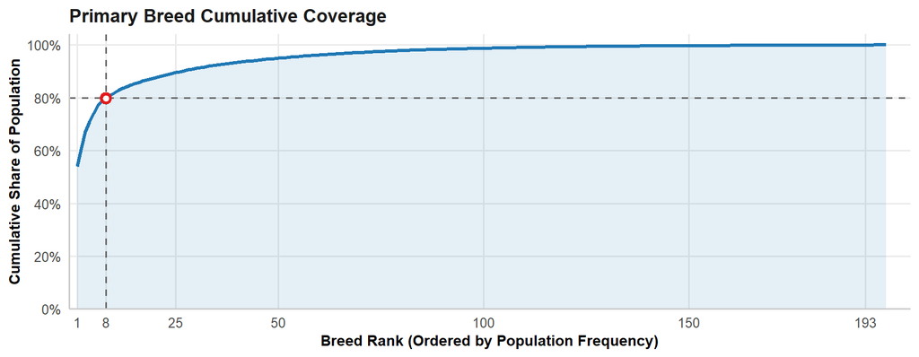

```r
library(ggplot2)
breed_summary <- data_selected %>%
  count(Primary.Breed, name = "Count") %>%
  arrange(desc(Count)) %>%
  mutate(
    Rank = row_number(),
    Pct = Count / sum(Count) * 100,
    Cum_Pct = cumsum(Pct)
  )

elbow_breed_rank <- 8
elbow_breed_val <- breed_summary$Cum_Pct[elbow_breed_rank]

# line plot for accumulated breed distribution
p_breed_elbow <- ggplot(breed_summary, aes(x = Rank, y = Cum_Pct)) +
  geom_area(fill = "#1f78b4", alpha = 0.12) +
  geom_line(color = "#1f78b4", linewidth = 1.2) +
  geom_hline(yintercept = 80, linetype = "dashed", color = "#666666", linewidth = 0.6) +
  geom_vline(xintercept = elbow_breed_rank, linetype = "dashed", color = "#666666", linewidth = 0.6) +
  geom_point(data = filter(breed_summary, Rank == elbow_breed_rank),
             color = "#e31a1c", size = 3.5) +
  geom_point(data = filter(breed_summary, Rank == elbow_breed_rank),
             color = "white", size = 1.5) +
  scale_x_continuous(
    breaks = c(1, 8, 25, 50, 100, 150, 193),
    expand = expansion(mult = c(0.01, 0.03))
  ) +
  scale_y_continuous(
    limits = c(0, 103),
    breaks = seq(0, 100, by = 20),
    labels = function(x) paste0(x, "%"),
    expand = expansion(mult = c(0, 0.01))
  ) +
  labs(
    title = "Primary Breed Cumulative Coverage",
    x = "Breed Rank (Ordered by Population Frequency)",
    y = "Cumulative Share of Population"
  ) +
  theme_minimal(base_size = 12) +
  theme(
    plot.title = element_text(face = "bold", size = 13, color = "#1a1a1a"),
    plot.subtitle = element_text(color = "#555555", margin = margin(b = 10)),
    panel.grid.minor = element_blank(),
    panel.grid.major = element_line(color = "#ebebeb"),
    axis.line = element_line(color = "#cccccc"),
    axis.title = element_text(face = "bold", size = 10.5)
  )

print(p_breed_elbow)
```

**4. Colour** — the raw data records `Primary.Color` and `Secondary.Color` separately, and most primary colours already map onto a small set of recognisable base colours. We first group `Primary.Color` into a `Base_Color` category, then derive a second feature, `has_pattern`, flagging animals that either have a non-empty `Secondary.Color` or whose primary colour description contains a patterned-coat keyword (Tabby, Brindle, Calico, Torbie, Point, Smoke, Tri Color, etc.) as “Mixed” rather than “Pure”. White/Cream animals show the highest Return-to-Owner proportion of any colour group, while Blue/Grey animals show a comparatively higher Euthanasia proportion in the proportional comparison below.

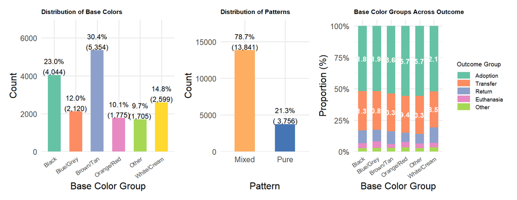

```r
# library(tidyverse)
#
# #
# raw_colors <- colour_eda$Primary.Color[!is.na(colour_eda$Primary.Color) & trimws(colour_eda$Primary.Color) != ""]
#
#
# tokens <- unlist(strsplit(tolower(raw_colors), "[^a-zA-Z]+"))
# tokens <- tokens[tokens != ""]
#
# word_freq <- as.data.frame(table(word = tokens), stringsAsFactors = FALSE) %>%
#   rename(n = Freq) %>%
#   arrange(desc(n)) %>%
#   mutate(pct = round(n / sum(n) * 100, 2))
# write.csv(word_freq, 'word_freq.csv')
# Group base_color type and Check if pattern
# Use a plotting copy; keep the original selected records unchanged.
colour_eda <- data_eda %>%
  mutate(
    Base_Color = case_when(
      str_detect(str_to_lower(Primary.Color), regex("brown|tan|choc|fawn|buff|sable|liver|cinnamon|rust|agouti|bronze|chestnut|sandy|seal", ignore_case = TRUE)) ~ "Brown/Tan",
      str_detect(str_to_lower(Primary.Color), regex("black|charcoal|sooty", ignore_case = TRUE)) ~ "Black",
      str_detect(str_to_lower(Primary.Color), regex("white|cream|blonde|albino|champagne|wheat|snow", ignore_case = TRUE)) ~ "White/Cream",
      str_detect(str_to_lower(Primary.Color), regex("blue|grey|gray|silver|lilac|wolf", ignore_case = TRUE)) ~ "Blue/Grey",
      str_detect(str_to_lower(Primary.Color), regex("orange|red|ginger|yellow|gold|apricot|lemon|flame", ignore_case = TRUE)) ~ "Orange/Red",
      TRUE ~ "Other"
    ),
    Base_Color = as.factor(Base_Color),
    has_pattern = if_else(
      (!is.na(Secondary.Color) & Secondary.Color != '') |
      str_detect(str_to_lower(Primary.Color), regex("tabby|brindle|smoke|Point|calico|torbie|tort|tri|merle|tiger|ticked|lynx|roan|bicolor|patch|shaded", ignore_case = TRUE)),
      "Mixed",
      "Pure"
    ),
    has_pattern = as.factor(has_pattern)
  )


# Base_Color distribution
p_base_bar <- ggplot(colour_eda, aes(x = Base_Color, fill = Base_Color)) +
  geom_bar(width = 0.6, show.legend = FALSE) +
  geom_text(
    stat = "count",
    aes(label = sprintf("%.1f%%\n(%s)",
                        after_stat(count) / sum(after_stat(count)) * 100,
                        format(after_stat(count), big.mark = ","))),
    vjust = -0.05,
    size = 3.2
  ) +
  scale_y_continuous(expand = expansion(mult = c(0, 0.30))) +
  scale_fill_brewer(palette = "Set2") +
  labs(
    title = "Distribution of Base Colors",
    x = "Base Color Group",
    y = "Count"
  ) +
  theme_minimal(base_size = 12) +
  theme(
    plot.title = element_text(face = "bold", size = 8),
    axis.text.x = element_text(angle = 35, hjust = 1, size = 7),
    panel.grid.minor = element_blank()
  )



# has_pattern distribution
p_pattern_bar <- ggplot(colour_eda, aes(x = has_pattern, fill = has_pattern)) +
  geom_bar(width = 0.5, show.legend = FALSE) +
  geom_text(
    stat = "count",
    aes(label = sprintf("%.1f%%\n(%s)",
                        after_stat(count) / sum(after_stat(count)) * 100,
                        format(after_stat(count), big.mark = ","))),
    vjust = -0.05,
    size = 3.2
  ) +
  scale_y_continuous(expand = expansion(mult = c(0, 0.30))) +
  scale_fill_manual(values = c("Pure" = "#4575b4", "Mixed" = "#fdae61")) +
  labs(
    title = "Distribution of Patterns",
    x = "Pattern",
    y = "Count"
  ) +
  theme_minimal(base_size = 12) +
  theme(
    plot.title = element_text(face = "bold", size = 8),
    panel.grid.minor = element_blank()
  )

base_outcome_pct <- colour_eda %>%
  count(Base_Color, Outcome.Group) %>%
  group_by(Base_Color) %>%
  mutate(
    Prop = n / sum(n),
    label_text = if_else(
      Outcome.Group %in% c("Adoption", "Transfer"),
      sprintf("%.1f%%", Prop * 100),
      ""
    )
  ) %>%
  ungroup()

p_base_vs_outcome <- ggplot(base_outcome_pct, aes(x = Base_Color, y = Prop, fill = Outcome.Group)) +
  geom_col(position = "fill", width = 0.6) +
  geom_text(
    aes(label = label_text),
    position = position_fill(vjust = 0.5),
    color = "white",
    fontface = "bold",
    size = 3.2
  ) +
  scale_y_continuous(labels = percent_format(), expand = expansion(mult = c(0, 0.05))) +
  scale_fill_brewer(palette = "Set2") +
  labs(
    title = "Base Color Groups Across Outcome",
    x = "Base Color Group",
    y = "Proportion (%)",
    fill = "Outcome Group"
  ) +
  theme_minimal(base_size = 12) +
  theme(
    plot.title = element_text(face = "bold", size = 8),
    axis.text.x = element_text(angle = 35, hjust = 1, size = 7),
    legend.position = "right",
    legend.title = element_text(size = 8),
    legend.text = element_text(size = 7),
    legend.key.height = grid::unit(0.35, "cm")
  )


p_base_bar + p_pattern_bar + p_base_vs_outcome+ plot_layout(widths = c(1.5, 1, 1))
```

**Additional predictor-outcome comparison.** The following figure compares the same pattern categories with outcome, alongside the original colour analysis above.

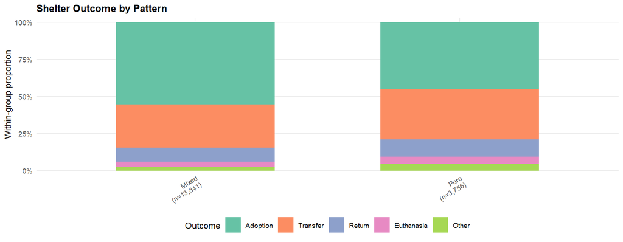

```r
p_pattern_outcome <- plot_outcome(
  colour_eda, "has_pattern", "Shelter Outcome by Pattern"
)
print(p_pattern_outcome)
```

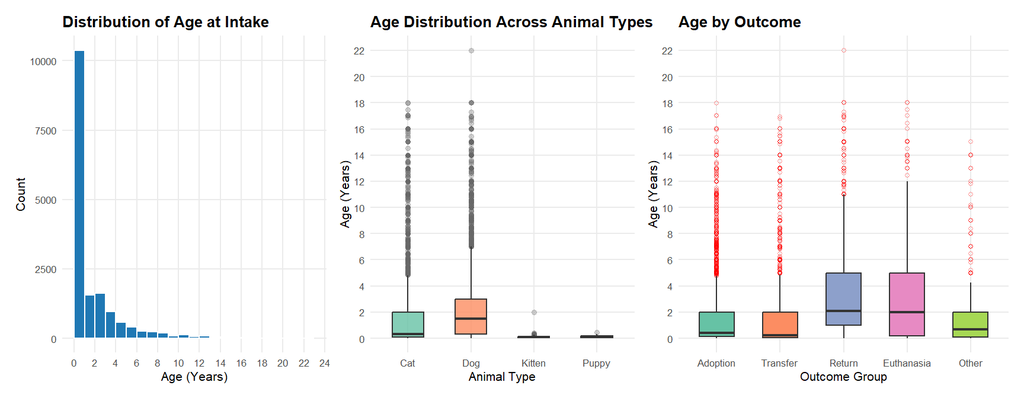

```r
library(lubridate)

# Calculate observed ages in a plotting copy only.
age_eda <- data_eda %>%
  # Use calendar dates, consistent with the audit and model features.
  mutate(
    DOB = parse_shelter_date(Date.of.Birth),
    Intake_Date = parse_shelter_date(Intake.Date),
    Age_Years = as.numeric(Intake_Date - DOB) / 365
  )

# Display observed nonnegative ages; do not replace or impute values in EDA.
# Missing and negative ages remain documented in the earlier data-quality audit.
age_eda <- age_eda %>%
  filter(!is.na(Age_Years), Age_Years >= 0)

# plot for age vs type, to check how to deal with missing value
p_age_by_type <- ggplot(age_eda, aes(x = Type, y = Age_Years, fill = Type)) +
  geom_boxplot(
    width = 0.5,
    alpha = 0.8,
    outlier.size = 1.2,
    outlier.alpha = 0.3,
    outlier.color = "grey40",
    show.legend = FALSE
  ) +
  scale_y_continuous(breaks = seq(0, 25, by = 2)) +
  scale_fill_brewer(palette = "Set2") +
  labs(
    title = "Age Distribution Across Animal Types",
    x = "Animal Type",
    y = "Age (Years)"
  ) +
  theme_minimal(base_size = 8) +
  theme(
    plot.title = element_text(face = "bold"),
    panel.grid.minor = element_blank()
  )

p_age_dist <- ggplot(filter(age_eda, !is.na(Age_Years), Age_Years >= 0), aes(x = Age_Years)) +
  geom_histogram(binwidth = 1, fill = "#1f78b4", color = "white", boundary = 0) +
  scale_x_continuous(breaks = seq(0, 25, by = 2)) +
  labs(
    title = "Distribution of Age at Intake",
    x = "Age (Years)",
    y = "Count"
  ) +
  theme_minimal(base_size = 8) +
  theme(plot.title = element_text(face = "bold"), panel.grid.minor = element_blank())



p_age_outcome <- ggplot(filter(age_eda, !is.na(Age_Years), Age_Years >= 0),
                        aes(x = Outcome.Group, y = Age_Years, fill = Outcome.Group)) +
  geom_boxplot(outlier.colour = "red", outlier.shape = 1, outlier.alpha = 0.4, width = 0.55, show.legend = FALSE) +
  scale_y_continuous(breaks = seq(0, 25, by = 2)) +
  scale_fill_brewer(palette = "Set2") +
  labs(
    title = "Age by Outcome",
    x = "Outcome Group",
    y = "Age (Years)"
  ) +
  theme_minimal(base_size = 8) +
  theme(
    plot.title = element_text(face = "bold"),
    panel.grid.minor = element_blank()
  )

p_age_dist + p_age_by_type + p_age_outcome + plot_layout(widths = c(0.8, 0.8, 1))
```

**6. Sex and Spayed/Neutered status** — both columns have a small number of missing values (recorded as `NA` or as an empty string, which we treat as equivalent), and `Spayed.Neutered` additionally has inconsistent capitalisation (`"Yes"` and `"yes"` both appear and represent the same value). Both issues are corrected in Data Preprocessing; the plots below use the raw values to document what the inconsistency actually looks like before cleaning.

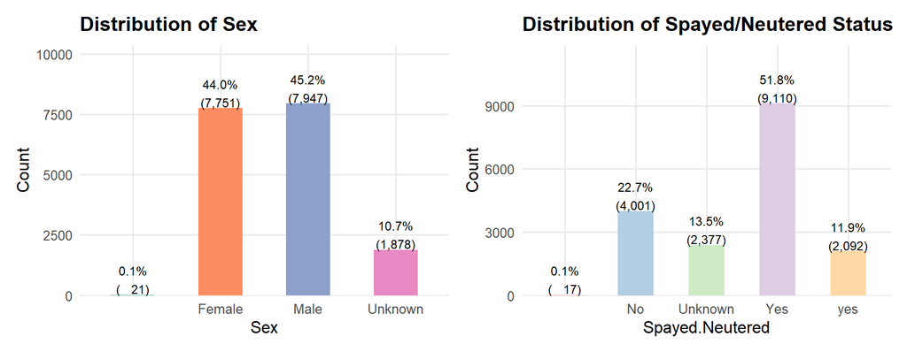

```r
p_sex_dist <- ggplot(data_selected, aes(x = Sex, fill = Sex)) +
  geom_bar(width = 0.5, show.legend = FALSE) +
  geom_text(
    stat = "count",
    aes(label = sprintf("%.1f%%\n(%s)",
                        after_stat(count) / sum(after_stat(count)) * 100,
                        format(after_stat(count), big.mark = ","))),
    vjust = -0.05, size = 3.2
  ) +
  scale_y_continuous(expand = expansion(mult = c(0, 0.30))) +
  scale_fill_brewer(palette = "Set2") +
  labs(
    title = "Distribution of Sex",
    x = "Sex",
    y = "Count") +
  theme_minimal(base_size = 12) +
  theme(
    plot.title = element_text(face = "bold", margin = margin(b = 8)),
    panel.grid.minor = element_blank()
  )

p_neuter_dist <- ggplot(data_selected, aes(x = Spayed.Neutered, fill = Spayed.Neutered)) +
  geom_bar(width = 0.5, show.legend = FALSE) +
  geom_text(
    stat = "count",
    aes(label = sprintf("%.1f%%\n(%s)",
                        after_stat(count) / sum(after_stat(count)) * 100,
                        format(after_stat(count), big.mark = ","))),
    vjust = -0.05, size = 3.2
  ) +
  scale_y_continuous(expand = expansion(mult = c(0, 0.30))) +
  scale_fill_brewer(palette = "Pastel1") +
  labs(title = "Distribution of Spayed/Neutered Status",
       x = "Spayed.Neutered",
       y = "Count") +
  theme_minimal(base_size = 12) +
  theme(
    plot.title = element_text(face = "bold", margin = margin(b = 8)),
    panel.grid.minor = element_blank()
  )

p_sex_dist + p_neuter_dist + plot_layout(widths = c(1, 1))
```

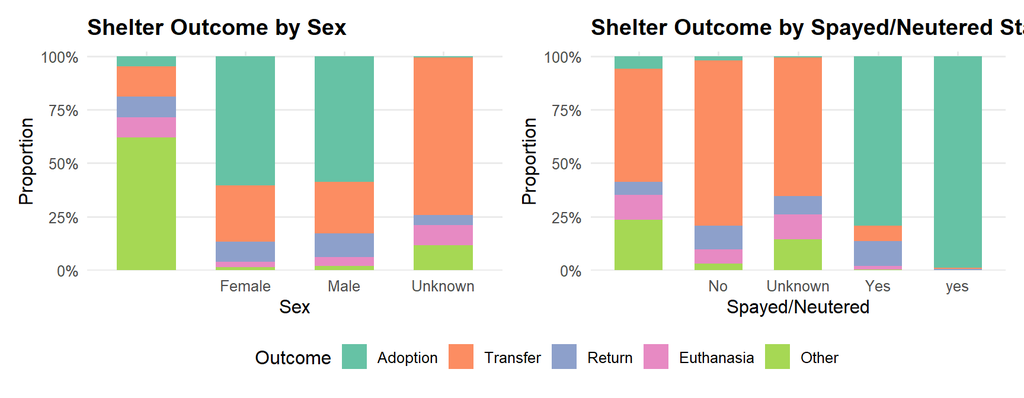

```r
p_sex_outcome <- ggplot(
  data_selected %>% filter(!is.na(Sex), !is.na(Outcome.Group)),
  aes(x = Sex, fill = Outcome.Group)
) +
  geom_bar(position = "fill", width = 0.6) +
  scale_y_continuous(
    labels = scales::percent_format(),
    expand = expansion(mult = c(0, 0.02))
  ) +
  scale_fill_brewer(palette = "Set2") +
  labs(
    title = "Shelter Outcome by Sex",
    x = "Sex",
    y = "Proportion",
    fill = "Outcome"
  ) +
  theme_minimal(base_size = 12) +
  theme(
    plot.title = element_text(face = "bold", margin = margin(b = 8)),
    panel.grid.minor = element_blank(),
    legend.position = "bottom"
  )


p_neuter_outcome <- ggplot(
  data_selected %>% filter(!is.na(Spayed.Neutered), !is.na(Outcome.Group)),
  aes(x = Spayed.Neutered, fill = Outcome.Group)
) +
  geom_bar(position = "fill", width = 0.6) +
  scale_y_continuous(
    labels = scales::percent_format(),
    expand = expansion(mult = c(0, 0.02))
  ) +
  scale_fill_brewer(palette = "Set2") +
  labs(
    title = "Shelter Outcome by Spayed/Neutered Status",
    x = "Spayed/Neutered",
    y = "Proportion",
    fill = "Outcome"
  ) +
  theme_minimal(base_size = 12) +
  theme(
    plot.title = element_text(face = "bold", margin = margin(b = 8)),
    panel.grid.minor = element_blank(),
    legend.position = "bottom"
  )


p_sex_outcome + p_neuter_outcome +
  plot_layout(widths = c(1, 1), guides = "collect") &
  theme(legend.position = "bottom")
```

**7. Name Recording** — EDA compares outcome proportions across observed recording conditions: non-placeholder text, placeholder text, blank text and NA. This is a missingness audit of `Name`, not construction of the binary `has_Name` predictor. Original names are retained; the binary modelling variable is created only in Data Preprocessing.

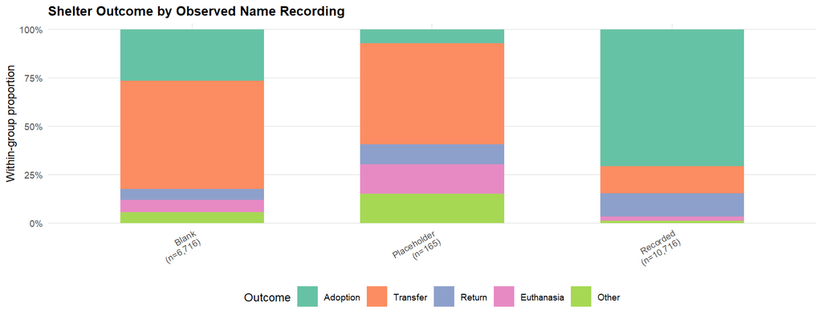

```r
# Whitespace/case checks identify placeholders for the audit
name_outcome_pct <- data_eda %>%
  group_by(Outcome.Group, .drop = FALSE) %>%
  summarise(
    Recorded = sum(
      !is_blank(Name) &
        !(str_to_lower(trimws(as.character(Name))) %in%
            c("unknown", "*", "n/a", "na"))
    ),
    Placeholder = sum(
      !is_blank(Name) &
        str_to_lower(trimws(as.character(Name))) %in%
          c("unknown", "*", "n/a", "na")
    ),
    Blank = sum(
      !is.na(Name) & trimws(as.character(Name)) == "",
      na.rm = TRUE
    ),
    Missing = sum(is.na(Name)),
    .groups = "drop"
  ) %>%
  pivot_longer(-Outcome.Group, names_to = "Level", values_to = "n") %>%
  group_by(Level) %>%
  mutate(
    Total = sum(n),
    Prop = if_else(Total > 0, n / Total, 0)
  ) %>%
  ungroup() %>%
  filter(Total > 0)

p_name_outcome <- plot_outcome_summary(
  name_outcome_pct, "Shelter Outcome by Observed Name Recording"
)
print(p_name_outcome)
```

Differences between these recording groups may reflect administrative practices or prior ownership information. This comparison cannot establish those explanations or confirm that names were available at intake.

**8. Implications for Modelling** — EDA has examined the information that will supply the eight candidate predictors. Type already contains age-related labels; breed and colour have many categories; date differences include missing and negative values; and Sex, Spayed/Neutered and Name contain recording issues. These findings motivate the explicit preprocessing choices in the next section. The class imbalance supports macro-F1 and per-class recall, while predictive value will be assessed using shared cross-validation splits.

## 4. Data Preprocessing

Model-input preprocessing begins here, after the EDA. The following steps translate the observed data-quality issues and associations into a common modelling dataset. The first step retains one record per animal, using the most recent intake date and time in the selected cat-and-dog subset. Fixed feature definitions are then applied to these retained records. Imputation values, retained breeds, factor levels and scaling parameters are then estimated from each training partition and applied unchanged to its validation or test partition.

The raw dates, names, breed and colour text are used to construct these predictors rather than being added again to the model. `ID`, `Animal.ID`, `Outcome.Date`, `Outcome.Status`, `Euthanasia.Reason`, `Days.in.Shelter`, and `Timestamp` are excluded from the predictor set. `Animal.ID` is used to select one record per animal and retained separately to check that training and assessment samples contain different animals.

The outcomes extract does not establish whether `Name` and `Spayed.Neutered` are their intake-time values. They remain candidate predictors for consistency with the model plan, but intake-time availability must be verified before interpreting the results as prospective predictions; otherwise, compare a version excluding them. A blank secondary colour is also not proof of a solid coat, so `has_pattern` is interpreted as a recording-based proxy.

1. **Latest intake record per animal**: retain the record with the most recent `Intake.Date` for each `Animal.ID`, including the recorded time. If intake timestamps tie, retain the first matching row in the source file; do not use the outcome to choose a record. Check that animal IDs and intake timestamps are available before selection. The modelling analysis therefore concerns each animal’s latest recorded admission within the selected subset, rather than all admission records.
2. **Type**: replace Puppy with Dog and Kitten with Cat, keeping the variable name `Type`. Do not include `Type_original` as a predictor.
3. **Age at intake**: parse the recorded dates, calculate `Age_Years`, and set negative ages to missing. Use calendar dates to avoid partial-day artefacts.
4. **Name**: create binary `has_Name`; missing values and placeholders are coded 0.
5. **Sex / Spayed.Neutered**: trim whitespace, standardise case, and represent missing or unrecognised labels as Unknown.
6. **Colour / breed text**: use the existing colour rules to derive `Base_Color` and `has_pattern`; trim breed labels. These fixed mappings do not depend on the outcome.
7. **Shared resampling**: use `caret::createDataPartition()` for an approximately 80/20 split stratified by `Outcome.Group`, then use `caret::createFolds()` to create five shared folds within training. Each animal contributes one record.
8. **Missing age**: estimate the median within the two-level `Type` in the training portion only. If a species has no observed training ages, use the overall training median. Do not impute using the original Puppy/Kitten categories.
9. **Primary Breed**: select the top eight nonmissing breeds in the training portion only; map all remaining and unseen breeds to Other. Apply the same fitted grouping to validation/test records.
10. **Feature exclusion and factor levels**: explicitly select the eight predictors, excluding identifiers, original text, dates, audit fields and outcome-derived information. Convert categorical predictors to factors and use the same levels in training and assessment data. The reference category, if needed, is chosen in each model’s section.
11. **Model-specific encoding**: prepare encoding within each model’s section as described in its code comments. Common preprocessing retains factors; any numeric encoding, zero-variance filtering and column alignment must use the corresponding training data.
12. **Model-specific scaling / class weights**: prepare these within each model’s section. Use training-derived age scaling where needed and training outcomes for any class weights. Common preprocessing leaves age unscaled; weighting remains a modelling choice.

```r
# Preprocessing 1. Retain one record per animal: its latest recorded intake.
# Keep the source row order so tied intake timestamps have a fixed rule.
data_latest <- data_selected %>%
  mutate(
    .source_row = row_number(),
    Intake_Datetime = parse_date_time(
      as.character(Intake.Date),
      orders = c("Y b d I M S p", "ymd HMS", "mdy HMS", "dmy HMS",
                 "ymd", "mdy", "dmy"),
      locale = "C", tz = "UTC", quiet = TRUE
    )
  )

data_latest <- data_latest %>%
  # Sort each animal's records from newest to oldest.
  # For equal timestamps, the first row in the source file comes first.
  arrange(Animal.ID, desc(Intake_Datetime), .source_row) %>%
  group_by(Animal.ID) %>%
  filter(row_number() == 1) %>%
  ungroup() %>%
  # Restore source order and remove the temporary selection columns.
  arrange(.source_row) %>%
  select(-.source_row, -Intake_Datetime)
```

This step retains **16,831 records for distinct animals** and removes 766 additional records. The final modelling sample still exceeds 10,000 observations. The preceding EDA describes the initial records; all model fitting, cross-validation and final evaluation use the retained latest-intake records.

```r
# Preprocessing 2-6. Construct model features from the retained latest-intake records.
prepare_features <- function(df) {
  df %>%
    mutate(
      # 2. Type-Age redundancy: Type now contains species only.
      Type_original = as.character(Type),
      Type = factor(case_when(
        Type_original %in% c("Dog", "Puppy") ~ "Dog",
        Type_original %in% c("Cat", "Kitten") ~ "Cat",
        TRUE ~ NA_character_
      ), levels = c("Cat", "Dog")),

      # 3. Age at intake: this is the first conversion of negative ages to NA.
      DOB = parse_shelter_date(Date.of.Birth),
      Intake_Date = parse_shelter_date(Intake.Date),
      Age_Years_raw = as.numeric(Intake_Date - DOB) / 365,
      Age_Years = if_else(Age_Years_raw < 0, NA_real_, Age_Years_raw),

      # 4. Name: treat blanks and case-insensitive placeholders as not recorded.
      has_Name = factor(if_else(
        is_blank(Name) | str_to_lower(trimws(as.character(Name))) %in%
          c("unknown", "*", "n/a", "na"), "0", "1"
      ), levels = c("0", "1")),

      # 5. Sex / Spayed.Neutered: standardise spelling, case and missing values.
      Sex = factor(case_when(
        str_to_lower(trimws(as.character(Sex))) == "male" ~ "Male",
        str_to_lower(trimws(as.character(Sex))) == "female" ~ "Female",
        TRUE ~ "Unknown"
      ), levels = c("Female", "Male", "Unknown")),
      Spayed.Neutered = factor(case_when(
        str_to_lower(trimws(as.character(Spayed.Neutered))) == "yes" ~ "Yes",
        str_to_lower(trimws(as.character(Spayed.Neutered))) == "no" ~ "No",
        TRUE ~ "Unknown"
      ), levels = c("No", "Yes", "Unknown")),

      # 6. Breed / Colour: fixed text cleaning; frequency grouping is deferred.
      Primary.Breed = if_else(is_blank(Primary.Breed), "Unknown",
                              trimws(as.character(Primary.Breed))),
      Base_Color = factor(case_when(
        is_blank(Primary.Color) ~ "Unknown",
        str_detect(Primary.Color, regex("brown|tan|choc|fawn|buff|sable|liver|cinnamon|rust|agouti|bronze|chestnut|sandy|seal", ignore_case = TRUE)) ~ "Brown/Tan",
        str_detect(Primary.Color, regex("black|charcoal|sooty", ignore_case = TRUE)) ~ "Black",
        str_detect(Primary.Color, regex("white|cream|blonde|albino|champagne|wheat|snow", ignore_case = TRUE)) ~ "White/Cream",
        str_detect(Primary.Color, regex("blue|grey|gray|silver|lilac|wolf", ignore_case = TRUE)) ~ "Blue/Grey",
        str_detect(Primary.Color, regex("orange|red|ginger|yellow|gold|apricot|lemon|flame", ignore_case = TRUE)) ~ "Orange/Red",
        TRUE ~ "Other"
      )),
      has_pattern = factor(case_when(
        !is_blank(Secondary.Color) |
          coalesce(str_detect(Primary.Color, regex(
            "tabby|brindle|smoke|point|calico|torbie|tort|tri|merle|tiger|ticked|lynx|roan|bicolor|patch|shaded",
            ignore_case = TRUE
          )), FALSE) ~ "Mixed",
        is_blank(Primary.Color) ~ "Unknown",
        TRUE ~ "Pure"
      ), levels = c("Pure", "Mixed", "Unknown"))
    )
}

data_features <- prepare_features(data_latest)
```

```r
# Preprocessing 7. Shared 80/20 split and 5 CV folds using caret.
library(caret)
set.seed(5003)

# createDataPartition returns the training row numbers, stratified by outcome.
train_index <- createDataPartition(
  data_features$Outcome.Group,
  p = 0.8,
  list = FALSE
)
train_raw <- data_features[train_index, ]
test_raw <- data_features[-train_index, ]
y_train <- train_raw$Outcome.Group
y_test <- test_raw$Outcome.Group

# Each list element contains the validation row numbers within train_raw.
cv_folds <- createFolds(
  y_train,
  k = 5,
  list = TRUE,
  returnTrain = FALSE
)
```

```r
# 8. Learn species-specific age medians from training only.
overall_age_median <- median(train_raw$Age_Years, na.rm = TRUE)
age_medians <- train_raw %>%
  group_by(Type) %>%
  summarise(Age_Median = median(Age_Years, na.rm = TRUE), .groups = "drop")

# 9. Select the eight most common recorded breeds in training.
top8_breeds <- train_raw %>%
  filter(Primary.Breed != "Unknown") %>%
  count(Primary.Breed, name = "Count") %>%
  arrange(desc(Count), Primary.Breed) %>%
  filter(row_number() <= 8) %>%
  pull(Primary.Breed)

# 10. Keep these eight predictors in x_train/x_test; y_train/y_test hold the outcome.
model_predictors <- c(
  "Type", "Sex", "Spayed.Neutered", "primary.breed.group",
  "Base_Color", "has_pattern", "has_Name", "Age_Years_imputed"
)
factor_predictors <- setdiff(model_predictors, "Age_Years_imputed")

# Apply steps 8-10 to training: fill missing ages and group breeds.
# Use the overall training median only if a species median is unavailable.
x_train <- train_raw %>%
  left_join(age_medians, by = "Type") %>%
  mutate(
    Age_Years_imputed = case_when(
      !is.na(Age_Years) ~ Age_Years,
      !is.na(Age_Median) ~ Age_Median,
      TRUE ~ overall_age_median
    ),
    primary.breed.group = if_else(
      Primary.Breed %in% top8_breeds, Primary.Breed, "Other"
    )
  ) %>%
  select(all_of(model_predictors))

# Apply the same training medians and breed list to the test data.
x_test <- test_raw %>%
  left_join(age_medians, by = "Type") %>%
  mutate(
    Age_Years_imputed = case_when(
      !is.na(Age_Years) ~ Age_Years,
      !is.na(Age_Median) ~ Age_Median,
      TRUE ~ overall_age_median
    ),
    primary.breed.group = if_else(
      Primary.Breed %in% top8_breeds, Primary.Breed, "Other"
    )
  ) %>%
  select(all_of(model_predictors))

# Use the same factor levels in training and test data.
for (variable in factor_predictors) {
  x_train[[variable]] <- factor(x_train[[variable]])
  x_test[[variable]] <- factor(
    x_test[[variable]],
    levels = levels(x_train[[variable]])
  )
}
```

```r
# Repeat steps 8-10 within each fold, starting from data before imputation.
# Learn the rules from fold_train only, then apply them to fold_valid.
cv_data <- list()
for (k in 1:5) {
  fold_train <- train_raw[-cv_folds[[k]], ]
  fold_valid <- train_raw[cv_folds[[k]], ]

  # 8. Age medians from this fold's training data.
  fold_overall_median <- median(fold_train$Age_Years, na.rm = TRUE)
  fold_age_medians <- fold_train %>%
    group_by(Type) %>%
    summarise(Age_Median = median(Age_Years, na.rm = TRUE), .groups = "drop")

  # 9. Top eight breeds from this fold's training data.
  fold_top8_breeds <- fold_train %>%
    filter(Primary.Breed != "Unknown") %>%
    count(Primary.Breed, name = "Count") %>%
    arrange(desc(Count), Primary.Breed) %>%
    filter(row_number() <= 8) %>%
    pull(Primary.Breed)

  # 8-10. Apply the rules and keep the common predictors.
  fold_train <- fold_train %>%
    left_join(fold_age_medians, by = "Type") %>%
    mutate(
      Age_Years_imputed = case_when(
        !is.na(Age_Years) ~ Age_Years,
        !is.na(Age_Median) ~ Age_Median,
        TRUE ~ fold_overall_median
      ),
      primary.breed.group = if_else(
        Primary.Breed %in% fold_top8_breeds, Primary.Breed, "Other"
      )
    ) %>%
    select(Outcome.Group, all_of(model_predictors))

  fold_valid <- fold_valid %>%
    left_join(fold_age_medians, by = "Type") %>%
    mutate(
      Age_Years_imputed = case_when(
        !is.na(Age_Years) ~ Age_Years,
        !is.na(Age_Median) ~ Age_Median,
        TRUE ~ fold_overall_median
      ),
      primary.breed.group = if_else(
        Primary.Breed %in% fold_top8_breeds, Primary.Breed, "Other"
      )
    ) %>%
    select(Outcome.Group, all_of(model_predictors))

  # 10. Use this fold's training factor levels for validation.
  for (variable in factor_predictors) {
    fold_train[[variable]] <- factor(fold_train[[variable]])
    fold_valid[[variable]] <- factor(
      fold_valid[[variable]],
      levels = levels(fold_train[[variable]])
    )
  }

  cv_data[[k]] <- list(
    x_train = select(fold_train, all_of(model_predictors)),
    y_train = fold_train$Outcome.Group,
    x_valid = select(fold_valid, all_of(model_predictors)),
    y_valid = fold_valid$Outcome.Group
  )
}

# Each cv_data[[k]] contains x_train, y_train, x_valid and y_valid.
# Validation data stay separate from the final x_test/y_test holdout.
# cv_folds[[k]] identifies the validation rows for out-of-fold predictions.
# This block prepares common data; model fitting/scoring belongs in each model section.

# Variable  Description
# x_train   Preprocessed predictors for the full training set (80%).
# y_train   Outcome labels for the full training set.
# x_test    Test predictors processed using the training-derived rules (20%).
# y_test    Outcome labels for final test evaluation.
# 5-fold CV : cv_data
```